# Lab | Introduction to R and Tidyverse

1. **Install and load the Tidyverse**: If you haven’t already, install the tidyverse package and load it into your R session.

```r
install.packages("tidyverse")
```

```
Error in install.packages : Updating loaded packages
```

```r
library(tidyverse)
```

2.**Create a data frame:** Use the following code to create a sample data frame for this exercise.

```r
employees <- data.frame(
          ID = 1:6,
          Name = c("Alice", "Bob", "Charlie", "David", "Eve", "Frank"),
          Age = c(25, 30, 35, 40, 45, 50),
          Department = c("HR", "IT", "Finance", "IT", "HR", "Finance"),
          Salary = c(50000, 60000, 70000, 80000, 55000, 75000)
        )
```

This data frame contains information about employees, including their ID, name, age, department, and salary.

### Task 1: Explore the Data

1. Print the employees data frame to the console.

```r
print(employees)
```

| ID | Name | Age | Department | Salary |
| --- | --- | --- | --- | --- |
| 1 | Alice | 25 | HR | 50000 |
| 2 | Bob | 30 | IT | 60000 |
| 3 | Charlie | 35 | Finance | 70000 |
| 4 | David | 40 | IT | 80000 |
| 5 | Eve | 45 | HR | 55000 |
| 6 | Frank | 50 | Finance | 75000 |

2. Use the str() function to inspect the structure of the data frame.

```r
str(employees)
```

```
'data.frame':   6 obs. of  5 variables:
 $ ID        : int  1 2 3 4 5 6
 $ Name      : chr  "Alice" "Bob" "Charlie" "David" ...
 $ Age       : num  25 30 35 40 45 50
 $ Department: chr  "HR" "IT" "Finance" "IT" ...
 $ Salary    : num  50000 60000 70000 80000 55000 75000
```

3. Use the summary() function to get a summary of the data.

```r
summary(employees)
```

```
       ID           Name                Age         Department            Salary
 Min.   :1.00   Length:6           Min.   :25.00   Length:6           Min.   :50000
 1st Qu.:2.25   Class :character   1st Qu.:31.25   Class :character   1st Qu.:56250
 Median :3.50   Mode  :character   Median :37.50   Mode  :character   Median :65000
 Mean   :3.50                      Mean   :37.50                      Mean   :65000
 3rd Qu.:4.75                      3rd Qu.:43.75                      3rd Qu.:73750
 Max.   :6.00                      Max.   :50.00                      Max.   :80000
```

### Task 2: Basic Data Manipulation with dplyr

1. Filter rows: Create a new data frame that includes only employees who work in the “IT” department.

```r
it_employees <- employees %>% filter(Department == "IT")
print(it_employees)
```

| ID | Name | Age | Department | Salary |
| --- | --- | --- | --- | --- |
| 2 | Bob | 30 | IT | 60000 |
| 4 | David | 40 | IT | 80000 |

2. Select columns: Create a new data frame that includes only the Name and Salary columns.

```r
name_salary_df<-employees %>% select(Name,Salary)
print(name_salary_df)
```

| Name | Salary |
| --- | --- |
| Alice | 50000 |
| Bob | 60000 |
| Charlie | 70000 |
| David | 80000 |
| Eve | 55000 |
| Frank | 75000 |

3. Add a new column: Add a new column called Bonus that calculates a 10% bonus for each employee based on their salary.

```r
mutated_df<- employees %>% mutate(Bonus=Salary*0.10)
print(mutated_df)
```

| ID | Name | Age | Department | Salary | Bonus |
| --- | --- | --- | --- | --- | --- |
| 1 | Alice | 25 | HR | 50000 | 5000 |
| 2 | Bob | 30 | IT | 60000 | 6000 |
| 3 | Charlie | 35 | Finance | 70000 | 7000 |
| 4 | David | 40 | IT | 80000 | 8000 |
| 5 | Eve | 45 | HR | 55000 | 5500 |
| 6 | Frank | 50 | Finance | 75000 | 7500 |

4. Sort rows: Sort the employees data frame by Salary in descending order.

```r
employees_sorted<-employees %>% arrange(desc(Salary))
print(employees_sorted)
```

| ID | Name | Age | Department | Salary |
| --- | --- | --- | --- | --- |
| 4 | David | 40 | IT | 80000 |
| 6 | Frank | 50 | Finance | 75000 |
| 3 | Charlie | 35 | Finance | 70000 |
| 2 | Bob | 30 | IT | 60000 |
| 5 | Eve | 45 | HR | 55000 |
| 1 | Alice | 25 | HR | 50000 |

5. Summarize data: Calculate the average salary for each department.

```r
average_salary_by_dept<- employees %>%
group_by(Department) %>%
summarize(Average_Salary=mean(Salary))
print(average_salary_by_dept)
```

| Department | Average_Salary |
| --- | --- |
| Finance | 72500 |
| HR | 52500 |
| IT | 70000 |

## Optional Exercises

### Extra 1: Advanced Data Manipulation

1. Group and summarize: Group the data by Department and calculate the total salary expenditure for each department.

```r
total_salary_exp_by_dept <- employees %>%
group_by(Department) %>%
summarize(Total_Salary = sum(Salary))
print(total_salary_exp_by_dept)
```

| Department | Total_Salary |
| --- | --- |
| Finance | 145000 |
| HR | 105000 |
| IT | 140000 |

2. Filter and mutate: Create a new data frame that includes only employees older than 30 and adds a column called Experience that assumes each employee has Age - 25 years of experience.

```r
employees_30_above_df <- employees %>%
filter(Age>30) %>%
mutate(Experience=Age-25)
print(employees_30_above_df)
```

| ID | Name | Age | Department | Salary | Experience |
| --- | --- | --- | --- | --- | --- |
| 3 | Charlie | 35 | Finance | 70000 | 10 |
| 4 | David | 40 | IT | 80000 | 15 |
| 5 | Eve | 45 | HR | 55000 | 20 |
| 6 | Frank | 50 | Finance | 75000 | 25 |

### Extra 2: Challenge

1. Combine operations: Create a new data frame that includes employees from the “HR” department, adds a Bonus column (10% of salary), and sorts the data by Bonus in descending order.

```r
HR_dept_df <- employees %>%
  filter(Department=="HR") %>%
  mutate(Bonus=Salary*0.10) %>%
  arrange(desc(Bonus))
print(HR_dept_df)
```

| ID | Name | Age | Department | Salary | Bonus |
| --- | --- | --- | --- | --- | --- |
| 5 | Eve | 45 | HR | 55000 | 5500 |
| 1 | Alice | 25 | HR | 50000 | 5000 |

2. Visualize data: Use ggplot2 to create a bar plot showing the total salary expenditure by department.

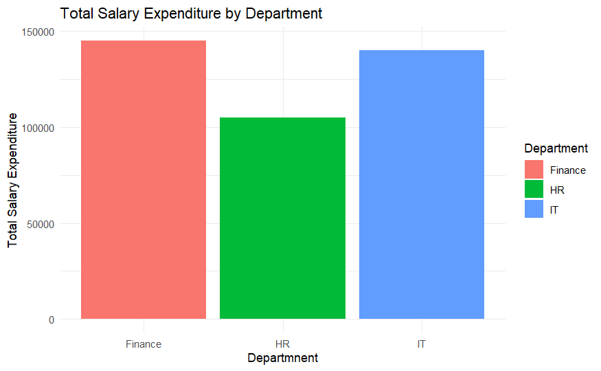

```r
library(ggplot2)
total_salary_by_dept <- employees %>%
  group_by(Department) %>%
  summarize(TotalSalary =sum(Salary))

  ggplot(total_salary_by_dept, aes(x=Department, y=TotalSalary, fill=Department))+
    geom_bar(stat='identity') +
    labs(title='Total Salary Expenditure by Department',
         x='Departmnent',
         y='Total Salary Expenditure') +
    theme_minimal()
```